# Praktikum 1

### Double Moving Average (DMA)

Metode pemulusan Double Moving Average (DMA) pada dasarnya mirip dengan SMA. Namun demikian, metode ini lebih cocok digunakan untuk pola data trend. Proses pemulusan dengan rata rata dalam metode ini dilakukan sebanyak 2 kali.

```r
dma <- SMA(data.sma, n = 3)
At <- 2*data.sma - dma
Bt <- 2/(4-1)*(data.sma - dma)
data.dma<- At+Bt
data.ramal2<- c(NA, data.dma)

t = 1:87
f = c()

for (i in t) {
  f[i] = At[length(At)] + Bt[length(Bt)]*(i)
}

data.gab2 <- cbind(aktual = c(train_ma.ts,rep(NA,87)), pemulusan1 = c(data.sma,rep(NA,87)),pemulusan2 = c(data.dma, rep(NA,87)),At = c(At, rep(NA,87)), Bt = c(Bt,rep(NA,87)),ramalan = c(data.ramal2, f[-1]))
data.gab2
```

```
##        aktual pemulusan1 pemulusan2       At           Bt  ramalan
##   [1,] 359.30         NA         NA       NA           NA       NA
##   [2,] 358.50         NA         NA       NA           NA       NA
##   [3,] 347.23         NA         NA       NA           NA       NA
##   [4,] 345.36   352.5975         NA       NA           NA       NA
##   [5,] 343.24   348.5825         NA       NA           NA       NA
##   [6,] 349.81   346.4100   341.7656 343.6233  -1.85777789       NA
##   [7,] 347.97   346.5950   345.5936 345.9942  -0.40055678 341.7656
##   [8,] 343.15   346.0425   345.5314 345.7358  -0.20444400 345.5936
##   [9,] 340.45   345.3450   344.2631 344.6958  -0.43277483 345.5314
##  [10,] 341.61   343.2950   340.6297 341.6958  -1.06611133 344.2631
##  [11,] 335.53   340.1850   335.5906 337.4283  -1.83777872 340.6297
##  [12,] 328.58   336.5425   330.7675 333.0775  -2.31000089 335.5906
##  [13,] 329.74   333.8650   328.8664 330.8658  -1.99944728 330.7675
##  [14,] 337.00   332.7125   329.9444 331.0517  -1.10722178 328.8664
```

[output cut: 199 more lines]

Hasil pemulusan menggunakan metode DMA divisualisasikan sebagai berikut

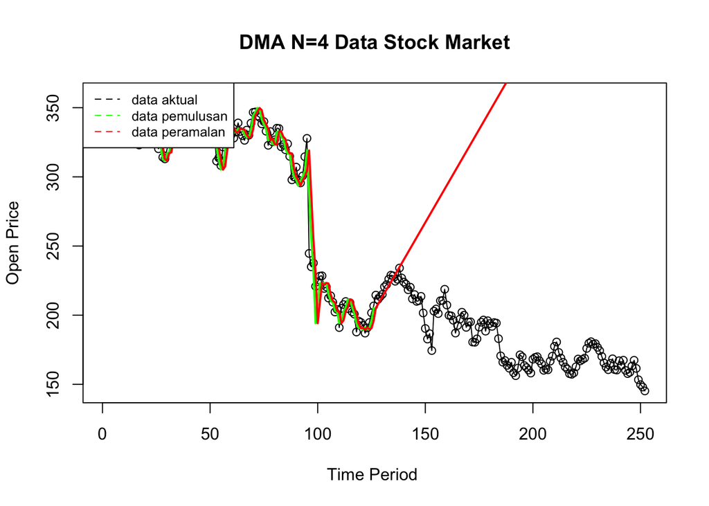

```r
ts.plot(data.ts, xlab="Time Period ", ylab="Open Price", main= "DMA N=4 Data Stock Market")
points(data.ts)
lines(data.gab2[,3],col="green",lwd=2)
lines(data.gab2[,6],col="red",lwd=2)
legend("topleft",c("data aktual","data pemulusan","data peramalan"), lty=8, col=c("black","green","red"), cex=0.8)
```

Selanjutnya perhitungan akurasi dilakukan baik pada data latih maupun data uji. Perhitungan akurasi dilakukan dengan ukuran akurasi SSE, MSE dan MAPE.

```r
#Menghitung nilai keakuratan data latih
error_train.dma = train_ma.ts-data.ramal2[1:length(train_ma.ts)]
SSE_train.dma = sum(error_train.dma[8:length(train_ma.ts)]^2)
MSE_train.dma = mean(error_train.dma[8:length(train_ma.ts)]^2)
MAPE_train.dma = mean(abs((error_train.dma[8:length(train_ma.ts)]/train_ma.ts[8:length(train_ma.ts)])*100))

akurasi_train.dma <- matrix(c(SSE_train.dma, MSE_train.dma, MAPE_train.dma))
row.names(akurasi_train.dma)<- c("SSE", "MSE", "MAPE")
colnames(akurasi_train.dma) <- c("Akurasi m = 4")
akurasi_train.dma
```

```
##      Akurasi m = 4
## SSE   17219.196326
## MSE     144.699129
## MAPE      2.780096
```

Perhitungan akurasi pada data latih menggunakan nilai MAPE menghasilkan nilai MAPE yang kurang dari 10% sehingga dikategorikan sangat baik. Selanjutnya, perhitungan nilai akurasi dilakukan pada data uji.

```r
#Menghitung nilai keakuratan data uji
error_test.dma = test_ma.ts-data.gab2[1:126,3]
```

```r
SSE_test.dma = sum(error_test.dma^2)
MSE_test.dma = mean(error_test.dma^2)
MAPE_test.dma = mean(abs((error_test.dma/test_ma.ts*100)))

akurasi_test.dma <- matrix(c(SSE_test.dma, MSE_test.dma, MAPE_test.dma))
row.names(akurasi_test.dma)<- c("SSE", "MSE", "MAPE")
colnames(akurasi_test.dma) <- c("Akurasi m = 4")
akurasi_test.dma
```

```
##      Akurasi m = 4
## SSE             NA
## MSE             NA
## MAPE            NA
```

## Single Exponential Smoothing & Double Exponential Smoothing

Metode *Exponential Smoothing* adalah metode pemulusan dengan melakukan pembobotan menurun secara eksponensial. Nilai yang lebih baru diberi bobot yang lebih besar dari nilai terdahulu. Terdapat satu atau lebih parameter pemulusan yang ditentukan secara eksplisit, dan hasil pemilihan parameter tersebut akan menentukan bobot yang akan diberikan pada nilai pengamatan. Ada dua macam model, yaitu model tunggal dan ganda.

### Pembagian Data

```r
#membagi training dan testing
training<-data[1:126,]
testing<-data[127:251,]
train.ts <- ts(training$Open)
test.ts <- ts(testing$Open)
```

### Eksplorasi

Eksplorasi dilakukan dengan membuat plot data deret waktu untuk keseluruhan data, data latih, dan data uji.

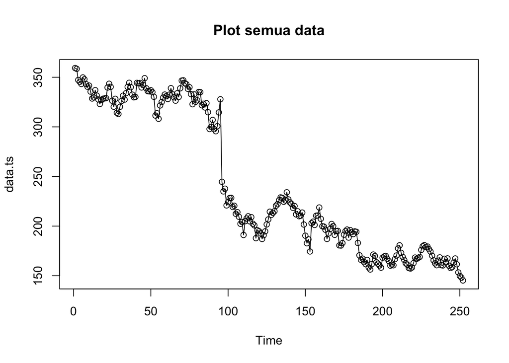

```r
#eksplorasi data
plot(data.ts, col="black",main="Plot semua data")
points(data.ts)
```

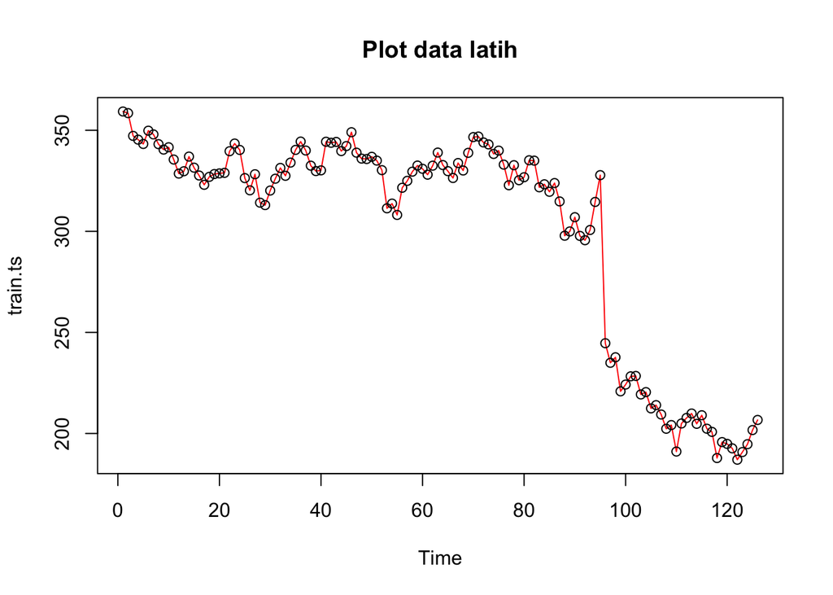

```r
plot(train.ts, col="red",main="Plot data latih")
points(train.ts)
```

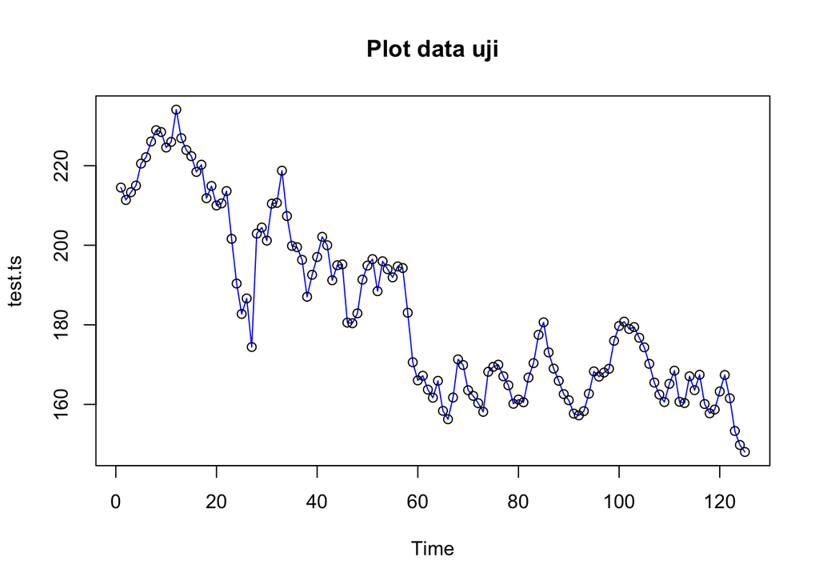

```r
plot(test.ts, col="blue",main="Plot data uji")
points(test.ts)
```

### SES

Single Exponential Smoothing merupakan metode pemulusan yang tepat digunakan untuk data dengan pola stasioner atau konstan.

Nilai pemulusan pada periode ke-t didapat dari persamaan:

$$\tilde{y}_T=\lambda y_t+(1-\lambda)\tilde{y}_{T-1}$$

Nilai parameter $\lambda$ adalah nilai antara 0 dan 1.

Nilai pemulusan periode ke-t bertindak sebagai nilai ramalan pada periode ke-$(T+\tau)$.

$$\tilde{y}_{T+\tau}(T)=\tilde{y}_T$$

Pemulusan dengan metode SES dapat dilakukan dengan dua fungsi dari *packages* berbeda, yaitu (1) fungsi `ses()` dari *packages* `forecast` dan (2) fungsi `HoltWinters` dari *packages* `stats` .

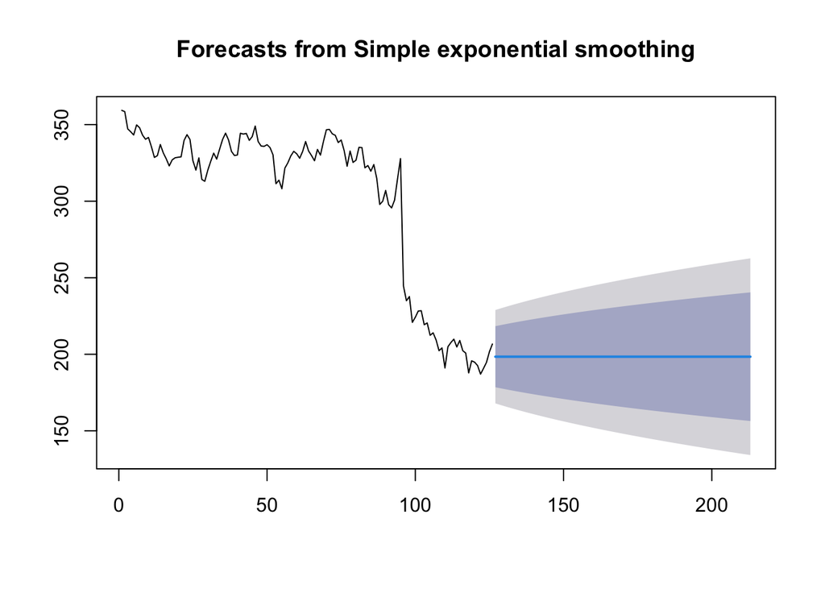

```r
#Cara 1 (fungsi ses)
ses.1 <- ses(train.ts, h = 87, alpha = 0.2)
plot(ses.1)
```

```r
ses.1
```

```
##     Point Forecast    Lo 80    Hi 80    Lo 95    Hi 95
## 127       198.4256 178.4911 218.3602 167.9383 228.9129
## 128       198.4256 178.0963 218.7550 167.3346 229.5167
## 129       198.4256 177.7090 219.1422 166.7423 230.1089
## 130       198.4256 177.3289 219.5224 166.1609 230.6903
## 131       198.4256 176.9554 219.8958 165.5898 231.2614
## 132       198.4256 176.5884 220.2628 165.0285 231.8228
## 133       198.4256 176.2274 220.6238 164.4764 232.3748
## 134       198.4256 175.8722 220.9790 163.9332 232.9180
## 135       198.4256 175.5225 221.3287 163.3984 233.4528
## 136       198.4256 175.1781 221.6731 162.8716 233.9796
## 137       198.4256 174.8387 222.0125 162.3526 234.4987
## 138       198.4256 174.5041 222.3471 161.8409 235.0104
## 139       198.4256 174.1742 222.6771 161.3362 235.5150
## 140       198.4256 173.8486 223.0026 160.8384 236.0129
```

[output cut: 73 more lines]

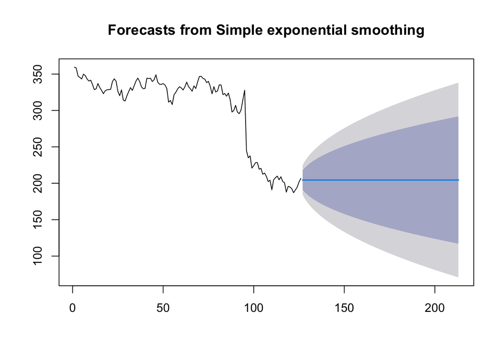

```r
ses.2<- ses(train.ts, h = 87, alpha = 0.7)
plot(ses.2)
```

```r
ses.2
```

```
##     Point Forecast    Lo 80    Hi 80     Lo 95    Hi 95
## 127       204.4493 191.1435 217.7552 184.09987 224.7988
## 128       204.4493 188.2075 220.6912 179.60965 229.2891
## 129       204.4493 185.7264 223.1723 175.81510 233.0836
## 130       204.4493 183.5376 225.3611 172.46763 236.4311
## 131       204.4493 181.5572 227.3415 169.43878 239.4599
## 132       204.4493 179.7349 229.1638 166.65187 242.2468
## 133       204.4493 178.0381 230.8606 164.05679 244.8419
## 134       204.4493 176.4439 232.4548 161.61865 247.2800
## 135       204.4493 174.9356 233.9631 159.31202 249.5867
## 136       204.4493 173.5008 235.3979 157.11767 251.7810
## 137       204.4493 172.1297 236.7690 155.02064 253.8781
## 138       204.4493 170.8143 238.0844 153.00902 255.8897
## 139       204.4493 169.5485 239.3502 151.07317 257.8255
## 140       204.4493 168.3271 240.5716 149.20511 259.6936
```

[output cut: 73 more lines]

Untuk mendapatkan gambar hasil pemulusan pada data latih dengan fungsi `ses()` , perlu digunakan fungsi `autoplot()` dan `autolayer()` dari *library packages* `ggplot2` .

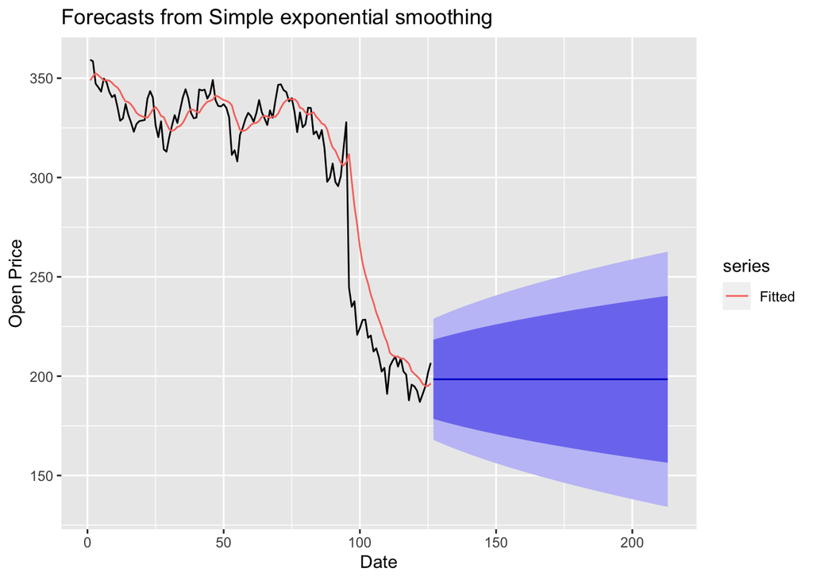

```r
library(ggplot2)
autoplot(ses.1) +
  autolayer(fitted(ses.1), series="Fitted") +
  ylab("Open Price") + xlab("Date")
```

Pada fungsi `ses()` , terdapat beberapa argumen yang umum digunakan, yaitu nilai `y` , `gamma` , `beta` , `alpha` , dan `h` .

Nilai `y` adalah nilai data deret waktu, `gamma` adalah parameter pemulusan untuk komponen musiman, `beta` adalah parameter pemulusan untuk tren, dan `alpha` adalah parameter pemulusan untuk stasioner, serta `h` adalah banyaknya periode yang akan diramalkan.

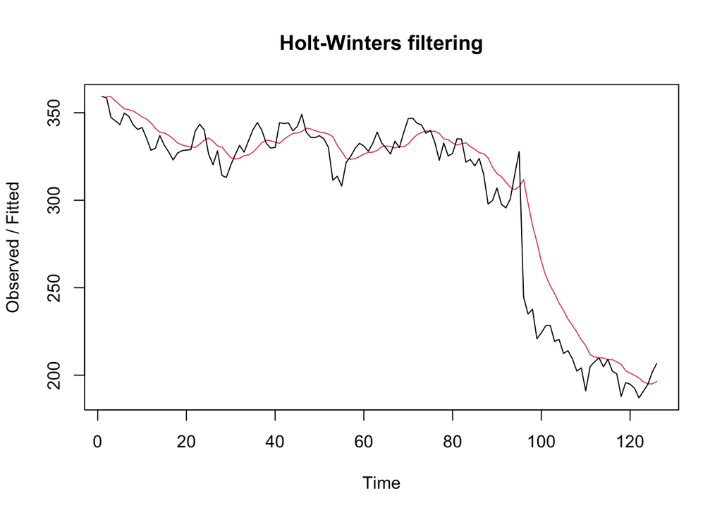

```r
#Cara 2 (fungsi Holtwinter)
ses1<- HoltWinters(train.ts, gamma = FALSE, beta = FALSE, alpha = 0.2)
plot(ses1)
```

```r
#ramalan
ramalan1<- forecast(ses1, h=126)
ramalan1
```

```
##     Point Forecast    Lo 80    Hi 80    Lo 95    Hi 95
## 127       198.4256 180.1817 216.6695 170.5240 226.3272
## 128       198.4256 179.8204 217.0308 169.9715 226.8798
## 129       198.4256 179.4660 217.3852 169.4294 227.4218
## 130       198.4256 179.1181 217.7331 168.8974 227.9539
## 131       198.4256 178.7764 218.0749 168.3747 228.4765
## 132       198.4256 178.4405 218.4108 167.8610 228.9903
## 133       198.4256 178.1101 218.7411 167.3557 229.4955
## 134       198.4256 177.7850 219.0662 166.8586 229.9927
## 135       198.4256 177.4650 219.3862 166.3691 230.4821
## 136       198.4256 177.1498 219.7014 165.8871 230.9642
## 137       198.4256 176.8392 220.0120 165.4120 231.4392
## 138       198.4256 176.5330 220.3183 164.9437 231.9075
## 139       198.4256 176.2310 220.6202 164.4819 232.3694
## 140       198.4256 175.9331 220.9182 164.0262 232.8250
```

[output cut: 112 more lines]

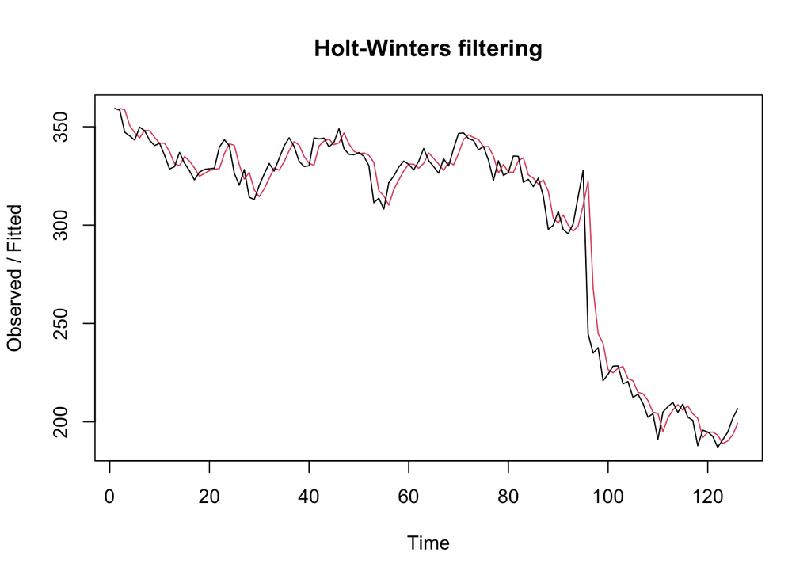

```r
ses2<- HoltWinters(train.ts, gamma = FALSE, beta = FALSE, alpha = 0.7)
plot(ses2)
```

```r
#ramalan
ramalan2<- forecast(ses2, h=126)
ramalan2
```

```
##     Point Forecast    Lo 80    Hi 80     Lo 95    Hi 95
## 127       204.4493 191.3389 217.5598 184.39863 224.5001
## 128       204.4493 188.4460 220.4527 179.97433 228.9244
## 129       204.4493 186.0013 222.8974 176.23548 232.6632
## 130       204.4493 183.8446 225.0541 172.93717 235.9615
## 131       204.4493 181.8933 227.0054 169.95278 238.9459
## 132       204.4493 180.0977 228.8010 167.20679 241.6919
## 133       204.4493 178.4258 230.4729 164.64980 244.2489
## 134       204.4493 176.8550 232.0437 162.24746 246.6512
## 135       204.4493 175.3689 233.5298 159.97470 248.9240
## 136       204.4493 173.9552 234.9435 157.81256 251.0861
## 137       204.4493 172.6041 236.2946 155.74632 253.1524
## 138       204.4493 171.3081 237.5906 153.76424 255.1345
## 139       204.4493 170.0609 238.8378 151.85680 257.0419
## 140       204.4493 168.8574 240.0413 150.01617 258.8825
```

[output cut: 112 more lines]

Fungsi `HoltWinters` memiliki argumen yang sama dengan fungsi `ses()` . Argumen-argumen kedua fungsi dapat dilihat lebih lanjut dengan `?ses()` atau `?HoltWinters` .

Nilai parameter $\alpha$ dari kedua fungsi dapat dioptimalkan menyesuaikan dari *error*-nya paling minimumnya. Caranya adalah dengan membuat parameter $\alpha =$ `NULL` .

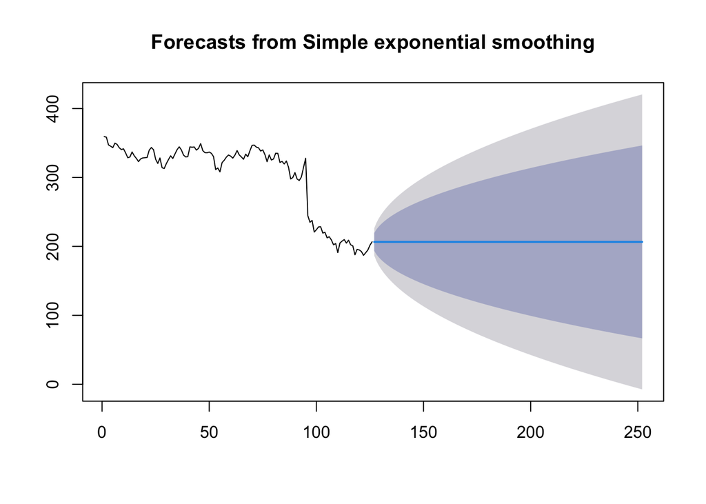

```r
#SES
ses.opt <- ses(train.ts, h = 126, alpha = NULL)
plot(ses.opt)
```

```r
ses.opt
```

```
##     Point Forecast     Lo 80    Hi 80       Lo 95    Hi 95
## 127       206.4998 193.55113 219.4485 186.6965134 226.3031
## 128       206.4998 188.53196 224.4676 179.0203516 233.9793
## 129       206.4998 184.63616 228.3634 173.0622460 239.9374
## 130       206.4998 181.33645 231.6632 168.0157779 244.9838
## 131       206.4998 178.42188 234.5777 163.5583294 249.4413
## 132       206.4998 175.78263 237.2170 159.5219345 253.4777
## 133       206.4998 173.35285 239.6468 155.8059168 257.1937
## 134       206.4998 171.08941 241.9102 152.3442856 260.6553
## 135       206.4998 168.96221 244.0374 149.0910055 263.9086
## 136       206.4998 166.94925 246.0504 146.0124490 266.9872
## 137       206.4998 165.03389 247.9657 143.0831651 269.9164
## 138       206.4998 163.20319 249.7964 140.2833403 272.7163
## 139       206.4998 161.44681 251.5528 137.5971913 275.4024
## 140       206.4998 159.75638 253.2432 135.0119029 277.9877
```

[output cut: 112 more lines]

```r
#Lamda Optimum Holt Winter
sesopt<- HoltWinters(train.ts, gamma = FALSE, beta = FALSE,alpha = NULL)
sesopt
```

```
## Holt-Winters exponential smoothing without trend and without seasonal component.
##
## Call:
## HoltWinters(x = train.ts, alpha = NULL, beta = FALSE, gamma = FALSE)
##
## Smoothing parameters:
##  alpha: 0.9621505
##  beta : FALSE
##  gamma: FALSE
##
## Coefficients:
##       [,1]
## a 206.5005
```

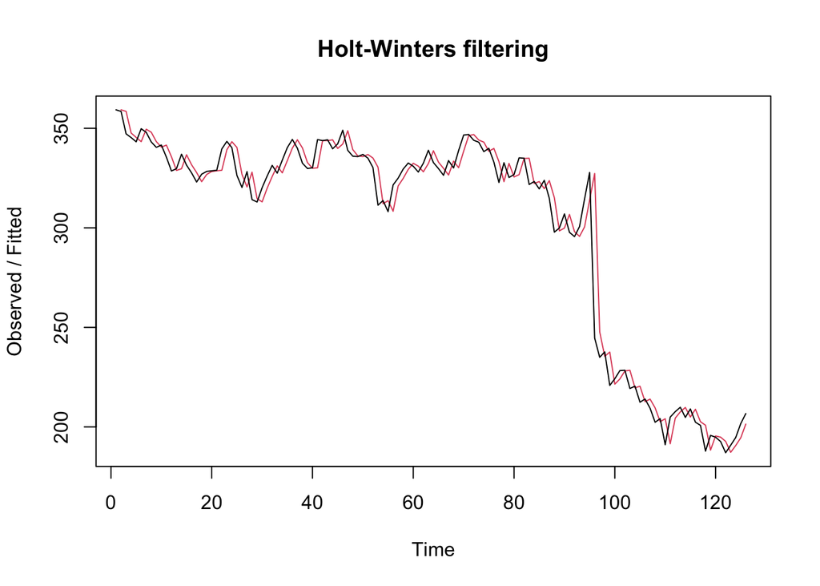

```r
plot(sesopt)
```

```r
#ramalan
ramalanopt<- forecast(sesopt, h=126)
ramalanopt
```

```
##     Point Forecast     Lo 80    Hi 80       Lo 95    Hi 95
## 127       206.5005 193.65543 219.3456 186.8556632 226.1453
## 128       206.5005 188.67530 224.3257 179.2392014 233.7618
## 129       206.5005 184.80995 228.1911 173.3276618 239.6733
## 130       206.5005 181.53608 231.4649 168.3207148 244.6803
## 131       206.5005 178.64436 234.3566 163.8982136 249.1028
## 132       206.5005 176.02581 236.9752 159.8934875 253.1075
## 133       206.5005 173.61511 239.3859 156.2066393 256.7944
## 134       206.5005 171.36945 241.6316 152.7721906 260.2288
## 135       206.5005 169.25895 243.7421 149.5444640 263.4565
## 136       206.5005 167.26181 245.7392 146.4900938 266.5109
## 137       206.5005 165.36150 247.6395 143.5838276 269.4172
## 138       206.5005 163.54518 249.4558 140.8060065 272.1950
## 139       206.5005 161.80261 251.1984 138.1409704 274.8600
## 140       206.5005 160.12547 252.8755 135.5760042 277.4250
```

[output cut: 112 more lines]

Setelah dilakukan peramalan, akan dilakukan perhitungan keakuratan hasil peramalan. Perhitungan akurasi ini dilakukan baik pada data latih dan data uji.

#### Akurasi Data Latih

Perhitungan akurasi data dapat dilakukan dengan cara langsung maupun manual. Secara langsung, nilai akurasi dapat diambil dari objek yang tersimpan pada hasil SES, yaitu *sum of squared errors* (SSE). Nilai akurasi lain dapat dihitung pula dari nilai SSE tersebut.

```r
#Keakuratan Metode
#Pada data training
SSE1<-ses1$SSE
MSE1<-ses1$SSE/length(train.ts)
RMSE1<-sqrt(MSE1)

akurasi1 <- matrix(c(SSE1,MSE1,RMSE1))
row.names(akurasi1)<- c("SSE", "MSE", "RMSE")
colnames(akurasi1) <- c("Akurasi lamda=0.2")
akurasi1
```

```
##      Akurasi lamda=0.2
## SSE        30305.57611
## MSE          240.52045
## RMSE          15.50872
```

```r
SSE2<-ses2$SSE
MSE2<-ses2$SSE/length(train.ts)
RMSE2<-sqrt(MSE2)

akurasi2 <- matrix(c(SSE2,MSE2,RMSE2))
row.names(akurasi2)<- c("SSE", "MSE", "RMSE")
colnames(akurasi2) <- c("Akurasi lamda=0.7")
akurasi2
```

```
##      Akurasi lamda=0.7
## SSE        13368.82368
## MSE          106.10178
## RMSE          10.30057
```

```r
#Cara Manual
fitted1<-ramalan1$fitted
sisaan1<-ramalan1$residuals
head(sisaan1)
```

```
## Time Series:
## Start = 1
## End = 6
## Frequency = 1
## [1]         NA  -0.799988 -11.909979 -11.398010 -11.238403  -2.420714
```

```r
resid1<-training$Open-ramalan1$fitted
head(resid1)
```

```
## Time Series:
## Start = 1
## End = 6
## Frequency = 1
## [1]         NA  -0.799988 -11.909979 -11.398010 -11.238403  -2.420714
```

```r
#Cara Manual
SSE.1=sum(sisaan1[2:length(train.ts)]^2)
SSE.1
```

```
## [1] 30305.58
```

```r
MSE.1 = SSE.1/length(train.ts)
MSE.1
```

```
## [1] 240.5204
```

```r
MAPE.1 = sum(abs(sisaan1[2:length(train.ts)]/train.ts[2:length(train.ts)])*
               100)/length(train.ts)
MAPE.1
```

```
## [1] 3.964101
```

```r
akurasi.1 <- matrix(c(SSE.1,MSE.1,MAPE.1))
row.names(akurasi.1)<- c("SSE", "MSE", "MAPE")
colnames(akurasi.1) <- c("Akurasi lamda=0.2")
akurasi.1
```

```
##      Akurasi lamda=0.2
## SSE       30305.576114
## MSE         240.520445
## MAPE          3.964101
```

```r
fitted2<-ramalan2$fitted
sisaan2<-ramalan2$residuals
head(sisaan2)
```

```
## Time Series:
## Start = 1
## End = 6
## Frequency = 1
## [1]         NA  -0.799988 -11.509985  -5.323022  -3.716901   5.454938
```

```r
resid2<-training$Open-ramalan2$fitted
head(resid2)
```

```
## Time Series:
## Start = 1
## End = 6
## Frequency = 1
## [1]         NA  -0.799988 -11.509985  -5.323022  -3.716901   5.454938
```

```r
SSE.2=sum(sisaan2[2:length(train.ts)]^2)
SSE.2
```

```
## [1] 13368.82
```

```r
MSE.2 = SSE.2/length(train.ts)
MSE.2
```

```
## [1] 106.1018
```

```r
MAPE.2 = sum(abs(sisaan2[2:length(train.ts)]/train.ts[2:length(train.ts)])*
               100)/length(train.ts)
MAPE.2
```

```
## [1] 2.29616
```

```r
akurasi.2 <- matrix(c(SSE.2,MSE.2,MAPE.2))
row.names(akurasi.2)<- c("SSE", "MSE", "MAPE")
colnames(akurasi.2) <- c("Akurasi lamda=0.7")
akurasi.2
```

```
##      Akurasi lamda=0.7
## SSE        13368.82368
## MSE          106.10178
## MAPE           2.29616
```

Berdasarkan nilai SSE, MSE, RMSE, dan MAPE di antara kedua parameter, nilai parameter $\lambda=0,7$ menghasilkan akurasi yang lebih baik dibanding $\lambda=0,2$ . Hal ini dilihat dari nilai masing-masing ukuran akurasi yang lebih kecil. Berdasarkan nilai MAPE-nya, hasil ini dapat dikategorikan sebagai peramalan sangat baik.

#### Akurasi Data Uji

Akurasi data uji dapat dihitung dengan cara yang hampir sama dengan perhitungan akurasi data latih.

```r
selisih1<-ramalan1$mean-testing$Open
SSEtesting1<-sum(selisih1^2)
MSEtesting1<-SSEtesting1/length(testing)

selisih2<-ramalan2$mean-testing$Open
SSEtesting2<-sum(selisih2^2)
MSEtesting2<-SSEtesting2/length(testing)

selisihopt<-ramalanopt$mean-testing$Open
SSEtestingopt<-sum(selisihopt^2)
MSEtestingopt<-SSEtestingopt/length(testing)

akurasitesting1 <- matrix(c(SSEtesting1,SSEtesting2,SSEtestingopt))
row.names(akurasitesting1)<- c("SSE1", "SSE2", "SSEopt")
akurasitesting1
```

```
##            [,1]
## SSE1    90711.4
## SSE2   117479.1
## SSEopt 128680.7
```

```r
akurasitesting2 <- matrix(c(MSEtesting1,MSEtesting2,MSEtestingopt))
row.names(akurasitesting2)<- c("MSE1", "MSE2", "MSEopt")
akurasitesting2
```

```
##            [,1]
## MSE1   45355.70
## MSE2   58739.56
## MSEopt 64340.37
```

```r
#cara lain
accuracy(ramalanopt,testing$Open)
```

```
##                      ME     RMSE       MAE         MPE      MAPE     MASE
## Training set  -1.270483 10.06341  6.049533  -0.5307875  2.159701 1.001419
## Test set     -22.942343 32.07700 27.994614 -14.1110716 16.380704 4.634132
##                     ACF1
## Training set -0.01172129
## Test set              NA
```

### DES

Metode pemulusan *Double Exponential Smoothing* (DES) digunakan untuk data yang memiliki pola tren. Metode DES adalah metode semacam SES, hanya saja dilakukan dua kali, yaitu pertama untuk tahapan ‘level’ dan kedua untuk tahapan ‘tren’. Pemulusan menggunakan metode ini akan menghasilkan peramalan tidak konstan untuk periode berikutnya.

Pemulusan dengan metode DES kali ini akan menggunakan fungsi `HoltWinters()` . Jika sebelumnya nilai argumen `beta` dibuat `FALSE` , kali ini argumen tersebut akan diinisialisasi bersamaan dengan nilai `alpha` .

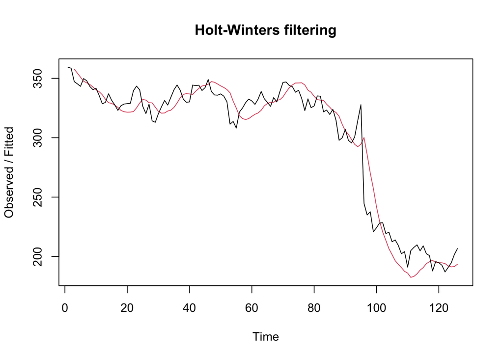

```r
#Lamda=0.2 dan gamma=0.2
des.1<- HoltWinters(train.ts, gamma = FALSE, beta = 0.2, alpha = 0.2)
plot(des.1)
```

```r
#ramalan
ramalandes1<- forecast(des.1, h=126)
ramalandes1
```

```
##     Point Forecast       Lo 80    Hi 80        Lo 95     Hi 95
## 127       196.6748  179.439591 213.9100  170.3158327  223.0337
## 128       197.1715  179.446839 214.8961  170.0639956  224.2789
## 129       197.6681  179.298292 216.0380  169.5738898  225.7624
## 130       198.1648  178.984891 217.3447  168.8316602  227.4979
## 131       198.6615  178.502931 218.8200  167.8316431  229.4913
## 132       199.1581  177.853332 220.4630  166.5752444  231.7410
## 133       199.6548  177.040568 222.2691  165.0693072  234.2403
## 134       200.1515  176.071520 224.2315  163.3243525  236.9786
## 135       200.6482  174.954433 226.3419  161.3529930  239.9433
## 136       201.1448  173.698102 228.5916  159.1686782  243.1210
## 137       201.6415  172.311288 230.9717  156.7848071  246.4982
## 138       202.1382  170.802352 233.4740  154.2141652  250.0622
## 139       202.6349  169.179049 236.0907  151.4686143  253.8011
## 140       203.1315  167.448442 238.8146  148.5589574  257.7041
```

[output cut: 112 more lines]

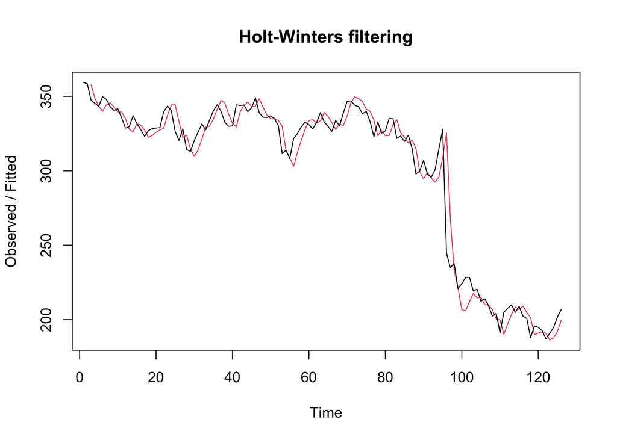

```r
#Lamda=0.6 dan gamma=0.3
des.2<- HoltWinters(train.ts, gamma = FALSE, beta = 0.3, alpha = 0.6)
plot(des.2)
```

```r
#ramalan
ramalandes2<- forecast(des.2, h=126)
ramalandes2
```

```
##     Point Forecast        Lo 80     Hi 80        Lo 95     Hi 95
## 127       206.7882   192.335517  221.2408   184.684752  228.8916
## 128       209.7868   191.457564  228.1160   181.754657  237.8189
## 129       212.7854   189.797099  235.7738   177.627813  247.9430
## 130       215.7841   187.501170  244.0670   172.529111  259.0390
## 131       218.7827   184.667126  252.8983   166.607432  270.9580
## 132       221.7813   181.360431  262.2022   159.962897  283.5998
## 133       224.7800   177.627147  271.9328   152.665949  296.8940
## 134       227.7786   173.501304  282.0559   144.768634  310.7886
## 135       230.7772   169.009165  292.5453   136.311119  325.2434
## 136       233.7759   164.171760  303.3800   127.325564  340.2262
## 137       236.7745   159.006431  314.5426   117.838493  355.7105
## 138       239.7732   153.527831  326.0185   107.872315  371.6740
## 139       242.7718   147.748580  337.7950    97.446331  388.0972
## 140       245.7704   141.679722  349.8611    86.577431  404.9634
```

[output cut: 112 more lines]

Selanjutnya jika ingin membandingkan plot data latih dan data uji adalah sebagai berikut.

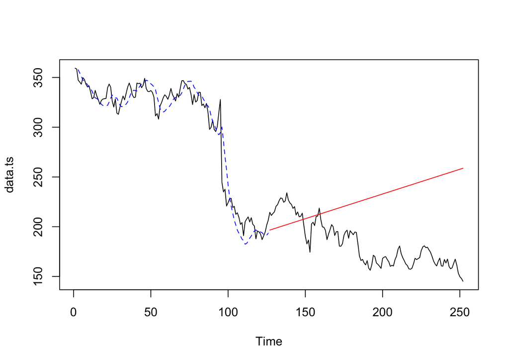

```r
#Visually evaluate the prediction
plot(data.ts)
lines(des.1$fitted[,1], lty=2, col="blue")
lines(ramalandes1$mean, col="red")
```

Untuk mendapatkan nilai parameter optimum dari DES, argumen `alpha` dan `beta` dapat dibuat `NULL` seperti berikut.

```r
#Lamda dan gamma optimum
des.opt<- HoltWinters(train.ts, gamma = FALSE)
des.opt
```

```
## Holt-Winters exponential smoothing with trend and without seasonal component.
##
## Call:
## HoltWinters(x = train.ts, gamma = FALSE)
##
## Smoothing parameters:
##  alpha: 0.9405633
##  beta : 0
##  gamma: FALSE
##
## Coefficients:
##         [,1]
## a 206.326669
## b  -0.799988
```

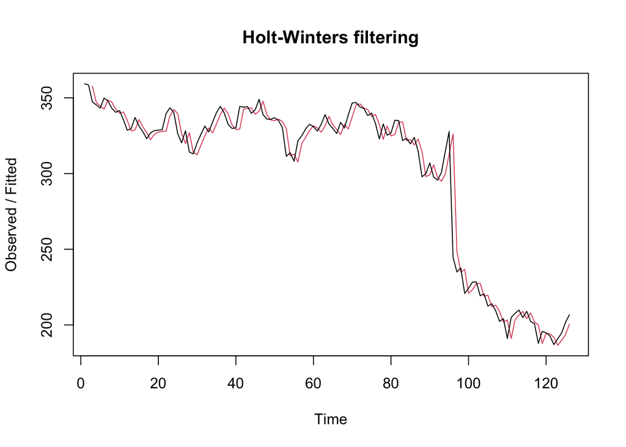

```r
plot(des.opt)
```

```r
#ramalan
ramalandesopt<- forecast(des.opt, h=126)
ramalandesopt
```

```
##     Point Forecast       Lo 80    Hi 80        Lo 95    Hi 95
## 127       205.5267 192.6323709 218.4210  185.8065354 225.2468
## 128       204.7267 187.0250111 222.4284  177.6543067 231.7991
## 129       203.9267 182.4689361 225.3845  171.1098793 236.7435
## 130       203.1267 178.4787525 227.7747  165.4309081 240.8225
## 131       202.3267 174.8565913 229.7969  160.3147788 244.3387
## 132       201.5267 171.4985081 231.5550  155.6025217 247.4510
## 133       200.7268 168.3418633 233.1116  151.1983382 250.2552
## 134       199.9268 165.3454494 234.5081  147.0392067 252.8143
## 135       199.1268 162.4804444 235.7731  143.0810477 255.1725
## 136       198.3268 159.7257527 236.9278  139.2915984 257.3620
## 137       197.5268 157.0653834 237.9882  135.6464027 259.4072
## 138       196.7268 154.4868720 238.9668  132.1263978 261.3272
## 139       195.9268 151.9802788 239.8734  128.7163824 263.1373
## 140       195.1268 149.5375265 240.7161  125.4040032 264.8497
```

[output cut: 112 more lines]

Selanjutnya akan dilakukan perhitungan akurasi pada data latih maupun data uji dengan ukuran akurasi SSE, MSE dan MAPE.

#### Akurasi Data Latih

```r
#Akurasi Data Training
ssedes.train1<-des.1$SSE
msedes.train1<-ssedes.train1/length(train.ts)
sisaandes1<-ramalandes1$residuals
head(sisaandes1)
```

```
## Time Series:
## Start = 1
## End = 6
## Frequency = 1
## [1]         NA         NA -10.470001  -9.027239  -7.761908   2.250835
```

```r
mapedes.train1 <- sum(abs(sisaandes1[3:length(train.ts)]/train.ts[3:length(train.ts)])
                      *100)/length(train.ts)

akurasides.1 <- matrix(c(ssedes.train1,msedes.train1,mapedes.train1))
row.names(akurasides.1)<- c("SSE", "MSE", "MAPE")
colnames(akurasides.1) <- c("Akurasi lamda=0.2 dan gamma=0.2")
akurasides.1
```

```
##      Akurasi lamda=0.2 dan gamma=0.2
## SSE                      22255.14740
## MSE                        176.62815
## MAPE                         3.54085
```

```r
ssedes.train2<-des.2$SSE
msedes.train2<-ssedes.train2/length(train.ts)
sisaandes2<-ramalandes2$residuals
head(sisaandes2)
```

```
## Time Series:
## Start = 1
## End = 6
## Frequency = 1
## [1]          NA          NA -10.4700010  -3.3734382  -0.1775632   9.8227511
```

```r
mapedes.train2 <- sum(abs(sisaandes2[3:length(train.ts)]/train.ts[3:length(train.ts)])
                      *100)/length(train.ts)

akurasides.2 <- matrix(c(ssedes.train2,msedes.train2,mapedes.train2))
row.names(akurasides.2)<- c("SSE", "MSE", "MAPE")
colnames(akurasides.2) <- c("Akurasi lamda=0.6 dan gamma=0.3")
akurasides.2
```

```
##      Akurasi lamda=0.6 dan gamma=0.3
## SSE                     15646.849145
## MSE                       124.181342
## MAPE                        2.530894
```

Hasil akurasi dari data latih didapatkan skenario 2 dengan lamda=0.6 dan gamma=0.3 memiliki hasil yang lebih baik. Namun untuk kedua skenario dapat dikategorikan peramalan sangat baik berdasarkan nilai MAPE-nya.

#### Akurasi Data Uji

```r
#Akurasi Data Testing
selisihdes1<-ramalandes1$mean-testing$Open
selisihdes1
```

```
## Time Series:
## Start = 127
## End = 252
## Frequency = 1
##   [1] -17.825219 -14.198542 -15.661876 -16.835201 -21.848523 -22.971860
##   [7] -26.415189 -28.758513 -27.801833 -23.405166 -24.338486 -31.941819
##  [13] -24.275148 -20.798464 -18.751803 -14.295123 -15.618457  -6.701786
##  [19]  -9.275105  -3.888433  -3.911764  -6.505088   6.001580  17.728263
##  [25]  25.864935  22.461599  35.158284   7.164952   6.121616   9.908298
##  [31]   1.124972   1.421648  -6.171690   5.724992  13.721665  14.548339
##  [37]  18.225005  27.991682  22.968351  18.995023  14.421704  17.038372
##  [43]  26.335048  23.061717  23.338389  38.475060  39.121742  37.138404
##  [49]  29.155081  26.121756  24.998433  33.555104  26.521778  29.008442
##  [55]  31.565127  29.321795  30.208467  41.945146  54.891816  59.948486
##  [61]  59.275161  63.251830  65.788511  62.035184  70.081845  72.688519
##  [67]  67.725200  58.631861  60.548547  67.375207  69.291893  71.628562
##  [73]  74.295234  64.731909  63.978582  63.945256  67.351918  70.118595
##  [79]  75.255267  74.691943  75.868624  70.155290  67.031968  60.408631
##  [85]  57.765304  65.821975  70.388655  73.945326  77.792005  79.818675
##  [91]  83.685344  84.622019  84.058694  80.175363  75.062035  76.868706
##  [97]  76.355384  75.902060  69.358725  66.135396  65.532078  67.878742
## [103]  67.895420  71.072100  73.988772  78.625444  83.832109  87.338791
## [109]  89.715454  85.632140  82.828810  91.145474  91.952145  85.728817
## [115]  89.715495  86.342173  94.188837  97.025521  96.572182  92.528862
## [121]  88.885536  95.232215 103.938879 107.965551 110.212224  44.258900
```

```r
SSEtestingdes1<-sum(selisihdes1^2)
MSEtestingdes1<-SSEtestingdes1/length(testing$Open)
MAPEtestingdes1<-sum(abs(selisihdes1/testing$Open)*100)/length(testing$Open)
selisihdes2<-ramalandes2$mean-testing$Open
selisihdes2
```

```
## Time Series:
## Start = 127
## End = 252
## Frequency = 1
##   [1]  -7.7118451  -1.5832039  -0.5445746   0.7840637  -1.7272950  -0.3486688
##   [7]  -1.2900345  -1.1313952   2.3272481   9.2258784  10.7945216   5.6931519
##  [13]  15.8617862  21.8404335  26.3890577  33.3477010  34.5263303  45.9449646
##  [19]  45.8736088  53.7622441  56.2408764  56.1495157  71.1581470  85.3867942
##  [25]  96.0254295  95.1240568 110.3227051  84.8313363  86.2899636  92.5786089
##  [31]  86.2972462  89.0958854  84.0045107  98.4031560 108.9017923 112.2304296
##  [37] 118.4090588 130.6776991 128.1563314 126.6849667 124.6136109 129.7322422
##  [43] 141.5308815 140.7595138 143.5381490 161.1767843 164.3254296 164.8440549
##  [49] 159.3626952 158.8313334 160.2099737 171.2686080 166.7372453 171.7258725
##  [55] 176.7845208 177.0431521 180.4317874 194.6704296 210.1190629 217.6776962
##  [61] 219.5063345 225.9849668 231.0236110 229.7722473 240.3208716 245.4295089
##  [67] 242.9681531 236.3767784 240.7954277 250.1240510 254.5427003 259.3813325
##  [73] 264.5499678 257.4886061 259.2372424 261.7058796 267.6145049 272.8831452
##  [79] 280.5217805 282.4604197 286.1390640 282.9276933 282.3063346 278.1849609
##  [85] 278.0435971 288.6022314 295.6708747 301.7295090 308.0781512 312.6067855
##  [91] 318.9754178 322.4140561 324.3526943 322.9713266 320.3599619 324.6685962
##  [97] 326.6572375 328.7058767 324.6645050 323.9431393 325.8417846 330.6904118
## [103] 333.2090531 338.8876964 344.3063317 351.4449669 359.1535952 365.1622405
## [109] 370.0408668 368.4595161 368.1581493 378.9767776 382.2854119 378.5640472
## [115] 385.0526884 384.1813297 394.5299570 399.8686043 401.9172286 400.3758718
## [121] 399.2345091 408.0831514 419.2917787 425.8204139 430.5690502 367.1176895
```

```r
SSEtestingdes2<-sum(selisihdes2^2)
MSEtestingdes2<-SSEtestingdes2/length(testing$Open)
MAPEtestingdes2<-sum(abs(selisihdes2/testing$Open)*100)/length(testing$Open)
selisihdesopt<-ramalandesopt$mean-testing$Open
selisihdesopt
```

```
## Time Series:
## Start = 127
## End = 252
## Frequency = 1
##   [1]   -8.973319   -6.643302   -9.403297  -11.873283  -18.183266  -20.603264
##   [7]  -25.343254  -28.983239  -29.323220  -26.223214  -28.453195  -37.353189
##  [13]  -30.983179  -28.803156  -28.053156  -24.893137  -27.513132  -19.893122
##  [19]  -23.763102  -19.673091  -20.993083  -24.883068  -13.673061   -3.243038
##  [25]    3.596973   -1.103024   10.297000  -18.992993  -21.332990  -18.842969
##  [31]  -28.922956  -29.922941  -38.812940  -28.212919  -21.512907  -21.982894
##  [37]  -19.602889  -11.132873  -17.452865  -22.722854  -28.592834  -27.272827
##  [43]  -19.272812  -23.842804  -24.862793  -11.022782  -11.672761  -14.952760
##  [49]  -24.232744  -28.562730  -30.982714  -23.722704  -32.052691  -30.862688
##  [55]  -29.602664  -33.142657  -33.552646  -23.112628  -11.462619   -7.702610
##  [61]   -9.672596   -6.992588   -5.752568  -10.802556   -4.052556   -2.742543
##  [67]   -9.002523  -19.392522  -18.772497  -13.242498  -12.622473  -11.582465
##  [73]  -10.212454  -21.072440  -23.122428  -24.452415  -22.342414  -20.872398
##  [79]  -17.032387  -18.892372  -19.012352  -26.022347  -30.442330  -38.362328
##  [85]  -42.302316  -35.542306  -32.272287  -30.012277  -27.462259  -26.732249
##  [91]  -24.162241  -24.522227  -26.382213  -31.562205  -37.972194  -37.462184
##  [97]  -39.272167  -41.022152  -48.862148  -53.382138  -55.282117  -54.232114
## [103]  -55.512097  -53.632078  -52.012067  -48.672056  -44.762052  -42.552031
## [109]  -41.472029  -46.852004  -50.951995  -43.931991  -44.421981  -51.941970
## [115]  -49.251953  -53.921936  -47.371933  -45.831910  -47.581910  -52.921891
## [121]  -57.861878  -52.811860  -45.401857  -42.671846  -41.721834 -108.971819
```

```r
SSEtestingdesopt<-sum(selisihdesopt^2)
MSEtestingdesopt<-SSEtestingdesopt/length(testing$Open)
MAPEtestingdesopt<-sum(abs(selisihdesopt/testing$Open)*100)/length(testing$Open)
akurasitestingdes <-
  matrix(c(SSEtestingdes1,MSEtestingdes1,MAPEtestingdes1,SSEtestingdes2,MSEtestingdes2,
           MAPEtestingdes2,SSEtestingdesopt,MSEtestingdesopt,MAPEtestingdesopt),
         nrow=3,ncol=3)
row.names(akurasitestingdes)<- c("SSE", "MSE", "MAPE")
colnames(akurasitestingdes) <- c("des ske1","des ske2","des opt")
akurasitestingdes
```

```
##          des ske1     des ske2      des opt
## SSE  432972.41810 7654171.3876 134111.20174
## MSE    3463.77934   61233.3711   1072.88961
## MAPE     29.75328     124.5017     15.97398
```

#### Perbandingan SES dan DES

```r
MSEfull <-
  matrix(c(MSEtesting1,MSEtesting2,MSEtestingopt,MSEtestingdes1,MSEtestingdes2,
           MSEtestingdesopt),nrow=3,ncol=2)
row.names(MSEfull)<- c("ske 1", "ske 2", "ske opt")
colnames(MSEfull) <- c("ses","des")
MSEfull
```

```
##              ses       des
## ske 1   45355.70  3463.779
## ske 2   58739.56 61233.371
## ske opt 64340.37  1072.890
```